# PRONOSTICOS REGRESIÓN

# Regresión lineal y principios de machine learning

Este notebook tiene como objetivo presentar los principios de la regresión lineal de modo que se puedan observar principios de aprendizaje de máquina (machine learning) en tareas supervisadas.

# Business understanding

Uno de los elementos claves de cualquier estrategia empresarial es movilizar los recursos hasta volverlos capacidades que permitan tener ventajas competitivas en el entorno empresarial.

Ejemplos de esas ventajas pueden ser un mejor precio (vía reducción de costos) o un producto de mayor calidad (vía diseño de producto/proceso).

El principal producto de Mao son tazones llenos de arroz, verduras y carne hechos a pedido del cliente.

El archivo muestra las ventas unitarias diarias del precio del Bowl/ tazón, Bowl, refrescos y cerveza.

Veamos el archivo:

```r
getwd()
```

```
## [1] "/Users/hugoalexandermartinezgallego/Desktop/mercadeo2016mac/0VARIOSHUGO/basesdatos"
```

Instalar paquete para importar dataset.

```r
library("readxl")
```

Revisar la estructura del objeto que se tiene y los diferentes tipos de datos mediante el comando str.

```r
maobase<-read_excel("MAOSBASE.xlsx")
```

```r
str(maobase)
```

```
## tibble [186 × 4] (S3: tbl_df/tbl/data.frame)
##  $ Bowl Price: num [1:186] 9.3 9.1 8.5 9.5 8.7 9.7 9.8 8.8 8.6 9.6 ...
##  $ Bowls     : num [1:186] 391 418 459 424 447 383 399 440 436 413 ...
##  $ Soda      : num [1:186] 313 326 358 331 380 291 307 361 344 351 ...
##  $ Beer      : num [1:186] 90 100 115 81 89 92 96 66 74 62 ...
```

El sector de cadenas rapidas de restaurantes crece en participación en Colombia, dada la varidad de comidas ofrecidas.

El principal producto de la cadena Mao´s son tazones llenos de arroz, verduras y carne hechos a pedido del cliente.

El archivo muestra las ventas unitarias diarias del precio del Bowl/ tazón, Bowl, refrescos y cerveza

La variable dependiente (o de respuesta) es Bowls número de tazones.

Las demás variables son posibles predictoras (variables independientes) e incluyen:

1-precio del Bowl/ tazón (Bowl Price)

2-venta de refrescos diarias (Soda)

3-venta de cervezas diarias (Beer)

# Aproximaciones al problema de predicción: estadística clásica vs. machine learning

Hay dos aproximaciones usuales a un problema de predicción:

Una aproximación estadística clásica y una aproximación de aprendizaje de máquina.

En la aproximación estadística clásica deben variarse las condiciones (valores) de las variables independientes de manera experimental para observar sus efectos en la variable de respuesta.

Dichas variables independientes deben escogerse idealmente bajo un fundamento teórico.

En esta aproximación, el cumplimiento de un conjunto de supuestos estadísticos es fundamental para demostrar la validez de la aproximación y su posible generalización a nuevos casos.

La capacidad explicativa del fenómeno es de alta relevancia, superior a la de su capacidad predictiva. Los resultados pueden interpretarse con total tranquilidad como resultados de causa y efecto si se ha realizado de manera experimental.

En la aproximación de machine learning con frecuencia la variación de los valores de las variables independientes no se han dado experimentalmente, sino en condiciones naturales del fenómeno. Dichas variables independientes se escogen ante todo dependiendo de su disponibilidad, por lo que podría haber factores/variables ocultas o intermedias.

El cumplimiento/violación de los suspuestos estadísticos no invalida el modelo, sino que da pistas sobre posibles mejoramientos.

La validación/generalización del modelo se da fundamentalmente por su capacidad predictiva en datos que no hacían parte de los que permitieron generar el modelo.

(Separación de las bases de entrenamiento y validación). La capacidad predictiva tiene una mayor importancia que la explicativa.

# Bases de entrenamiento y validación.

Al momento de generar bases de entrenamiento y validación, la primera y más básica aproximación es dividir la base de datos en dos: entrenamiento y validación.

No existe un criterio único y definido para saber qué porcentaje de la base de datos debe entregarse a entrenamiento y cuál a validación.

De manera empírica, con frecuencia se usa el 70%-80% de los datos para la base de entrenamiento y el 30%-20% de los datos para la base de validación.

Obtengo una muestra, se deja alguna semilla para que el muestreo sea replicable.

```r
set.seed(920203)
```

Aquí se define el tamaño de la muestra, en este caso entrenamiento tendría el 80% de los casos.

```r
sample <- sample.int(nrow(maobase), floor(.8*nrow(maobase)))
maobase.train <- maobase[sample, ]
maobase.test <- maobase[-sample, ]
```

```r
str(maobase.train)
```

```
## tibble [148 × 4] (S3: tbl_df/tbl/data.frame)
##  $ Bowl Price: num [1:148] 8.5 10 8 10 8.3 8.5 8.6 9.5 8.1 9.4 ...
##  $ Bowls     : num [1:148] 441 386 457 400 434 467 431 416 480 426 ...
##  $ Soda      : num [1:148] 375 293 356 324 356 369 332 354 374 337 ...
##  $ Beer      : num [1:148] 88 97 82 84 87 93 86 71 115 98 ...
```

```r
str(maobase.test)
```

```
## tibble [38 × 4] (S3: tbl_df/tbl/data.frame)
##  $ Bowl Price: num [1:38] 8.7 9.7 9.9 8.7 8.8 9.5 10 9.7 9.9 8.8 ...
##  $ Bowls     : num [1:38] 447 383 381 428 459 421 379 406 387 443 ...
##  $ Soda      : num [1:38] 380 291 312 321 386 354 284 325 298 346 ...
##  $ Beer      : num [1:38] 89 92 95 64 73 76 87 85 74 71 ...
```

# Aproximación estadística clásica

Vamos a crear dos modelos lineales clásicos.

En ellos, las variables independientes se definen de antemano, es decir, son preespecificadas.

# Entendimiento de datos

Carga del paquete psych

```r
library(psych)
```

Resumen general de las variables del objeto maobase

```r
summary(maobase)
```

```
##    Bowl Price         Bowls            Soda            Beer
##  Min.   : 8.000   Min.   :379.0   Min.   :284.0   Min.   : 57.00
##  1st Qu.: 8.500   1st Qu.:411.2   1st Qu.:324.0   1st Qu.: 73.00
##  Median : 9.000   Median :427.5   Median :340.0   Median : 86.00
##  Mean   : 9.035   Mean   :428.5   Mean   :340.9   Mean   : 84.97
##  3rd Qu.: 9.500   3rd Qu.:446.8   3rd Qu.:359.8   3rd Qu.: 96.00
##  Max.   :10.000   Max.   :487.0   Max.   :414.0   Max.   :119.00
```

Uso de la función describe que realiza múltiples descriptivos

```r
describe(maobase)
```

```
##            vars   n   mean    sd median trimmed   mad min max range  skew
## Bowl Price    1 186   9.04  0.59    9.0    9.04  0.74   8  10     2 -0.06
## Bowls         2 186 428.47 24.73  427.5  428.11 25.95 379 487   108  0.14
## Soda          3 186 340.92 25.10  340.0  340.85 25.95 284 414   130  0.09
## Beer          4 186  84.97 14.45   86.0   84.68 17.79  57 119    62  0.13
##            kurtosis   se
## Bowl Price    -1.18 0.04
## Bowls         -0.61 1.81
## Soda          -0.40 1.84
## Beer          -0.89 1.06
```

Observar la correlación entre los datos

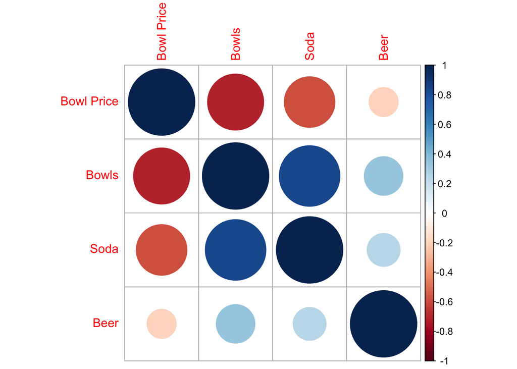

```r
## Carga de paquetes
library(corrplot)
matrizcor<-cor(maobase)
corrplot(matrizcor)
```

Afinemos la matriz de correlación.

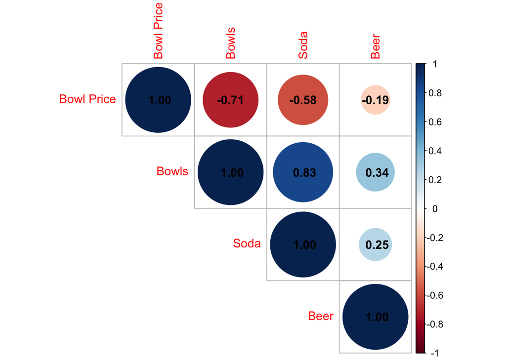

```r
corrplot(matrizcor, type="upper", method="circle", addCoef.col = "black")
```

Se pueden observar algunas asociaciones con la variable dependiente.

Para los modelos estadísticos clásicos, la capacidad explicativa puede verse reducida por la razón anterior, y por cambios de signo en los coeficientes que hacen los resultados no interpretables.

# Realización de modelos.

Un posible primer modelo implica que el precio de Bowl es un posible predictor.

Un segundo modelo va a contener todas las variables que fueron recogidas, puesto que todas tenían algun tipo de sustento empírico y teórico.

Cargando la libreria para realizar los modelos de regresión.

```r
library('lmtest')
library(zoo)
```

Un modelo0 con variables elegidas (preespecificado - Bowl Price)

```r
modelo0<- lm(Bowls ~ `Bowl Price`, data=maobase)
```

Un modelo1 con todas las variables (preespecificado)

```r
modelo1<- lm(Bowls ~.,data=maobase)
```

# Valoración de modelos

Una vez obtenidos los modelos se pasa a revisar sus métricas de ajuste (calidad) y el cumplimiento de supuestos.

```r
#pruebas de hipotesis y dos metricas
summary(modelo0)
```

```
##
## Call:
## lm(formula = Bowls ~ `Bowl Price`, data = maobase)
##
## Residuals:
##      Min       1Q   Median       3Q      Max
## -29.6449 -15.8172   0.3551  13.9835  30.8417
##
## Coefficients:
##              Estimate Std. Error t value Pr(>|t|)
## (Intercept)   695.874     19.491   35.70   <2e-16 ***
## `Bowl Price`  -29.595      2.152  -13.75   <2e-16 ***
## ---
## Signif. codes:  0 '***' 0.001 '**' 0.01 '*' 0.05 '.' 0.1 ' ' 1
##
## Residual standard error: 17.42 on 184 degrees of freedom
## Multiple R-squared:  0.5067, Adjusted R-squared:  0.5041
## F-statistic:   189 on 1 and 184 DF,  p-value: < 2.2e-16
```

```r
summary(modelo1)
```

```
##
## Call:
## lm(formula = Bowls ~ ., data = maobase)
##
## Residuals:
##     Min      1Q  Median      3Q     Max
## -27.969  -7.205  -1.112   8.608  27.775
##
## Coefficients:
##               Estimate Std. Error t value Pr(>|t|)
## (Intercept)  333.47353   27.05468  12.326  < 2e-16 ***
## `Bowl Price` -13.98369    1.76226  -7.935 2.08e-13 ***
## Soda           0.59623    0.04230  14.096  < 2e-16 ***
## Beer           0.21275    0.06096   3.490 0.000606 ***
## ---
## Signif. codes:  0 '***' 0.001 '**' 0.01 '*' 0.05 '.' 0.1 ' ' 1
##
## Residual standard error: 11.58 on 182 degrees of freedom
## Multiple R-squared:  0.7842, Adjusted R-squared:  0.7807
## F-statistic: 220.5 on 3 and 182 DF,  p-value: < 2.2e-16
```

Ahora tomemos Aprendizaje de Maquina para trabajar sobre las bases de entrenamiento y prueba.

```r
modelot0<- lm(Bowls ~ `Bowl Price`, data=maobase.train)
```

Un modelo1 con todas las variables (preespecificado)

```r
modelot1<- lm(Bowls ~.,data=maobase.train)
```

Pruebas de hipotesis y dos metricas para el dataset de entrenamiento.

```r
summary(modelot0)
```

```
##
## Call:
## lm(formula = Bowls ~ `Bowl Price`, data = maobase.train)
##
## Residuals:
##      Min       1Q   Median       3Q      Max
## -29.8581 -15.9475  -0.0557  14.3889  30.7347
##
## Coefficients:
##              Estimate Std. Error t value Pr(>|t|)
## (Intercept)   695.264     21.880   31.78   <2e-16 ***
## `Bowl Price`  -29.506      2.422  -12.18   <2e-16 ***
## ---
## Signif. codes:  0 '***' 0.001 '**' 0.01 '*' 0.05 '.' 0.1 ' ' 1
##
## Residual standard error: 17.52 on 146 degrees of freedom
## Multiple R-squared:  0.504,  Adjusted R-squared:  0.5006
## F-statistic: 148.4 on 1 and 146 DF,  p-value: < 2.2e-16
```

```r
summary(modelot1)
```

```
##
## Call:
## lm(formula = Bowls ~ ., data = maobase.train)
##
## Residuals:
##     Min      1Q  Median      3Q     Max
## -27.623  -7.788  -1.020   8.471  27.779
##
## Coefficients:
##               Estimate Std. Error t value Pr(>|t|)
## (Intercept)  334.56208   31.01573  10.787  < 2e-16 ***
## `Bowl Price` -14.29183    1.99650  -7.158 3.85e-11 ***
## Soda           0.59429    0.05039  11.793  < 2e-16 ***
## Beer           0.23885    0.07051   3.387  0.00091 ***
## ---
## Signif. codes:  0 '***' 0.001 '**' 0.01 '*' 0.05 '.' 0.1 ' ' 1
##
## Residual standard error: 11.81 on 144 degrees of freedom
## Multiple R-squared:  0.7775, Adjusted R-squared:  0.7729
## F-statistic: 167.8 on 3 and 144 DF,  p-value: < 2.2e-16
```

En este resumen, se observan las primeras y más básicas evaluaciones del modelo de regresión. Tenemos dos pruebas de hipótesis y dos métricas de ajuste.

Miremos primero la prueba de hipótesis (F statistics). Se trata de una prueba básica en la que, si la regresión explica un poco más que el error (el modelo explica más que el azar), el valor p será pequeño.

A menos que las variables independientes tengan muy baja asociación con la dependiente, esta prueba se verificará y nos dirá que el modelo tiene un mínimo nivel de validez predictiva.

Más interesantes son las pruebas de hipótesis t individuales para cada variable independiente (Pr > |t|), en las que se prueba si cada coeficiente es o no diferente de cero, lo que da una idea de si la inclusión de cada una de las variables valió la pena en el modelo (el asunto es un poco más complejo porque las interacciones y el tipo de relación cuentan.

En nuestros dos modelos tienen variables con coeficientes significativos. También podemos obtener intervalos de confianza para los coeficientes:

```r
#Intervalos de confianza
confint(modelot0, level=0.95)
```

```
##                  2.5 %    97.5 %
## (Intercept)  652.02234 738.50534
## `Bowl Price` -34.29336 -24.71863
```

```r
confint(modelot1, level=0.95)
```

```
##                     2.5 %      97.5 %
## (Intercept)  273.25716649 395.8670000
## `Bowl Price` -18.23807212 -10.3455945
## Soda           0.49468967   0.6938950
## Beer           0.09947681   0.3782284
```

Las dos métricas que se presentan son:

El r2 (ajustado) y el error estándar promedio de los residuales (error residual).

El r2 nos indica el porcentaje de la variabilidad de la variable dependiente (El total de Bowls) que las variables dependientes logran explicar.

El error residual nos dice a cuánto asciende, en promedio, la variabilidad que no se ha logrado explicar, en dimensiones de la variable dependiente. En ese sentido, es muy útil para valorar desde el negocio y la operación si el modelo es viable.

Que este error sea aceptable/manejable o no depende del contexto del negocio. En operaciones y finanzas estos valores pueden ayudar a calcular márgenes de contingencia o tolerancia que mejoren la planeación y permitan estar preparados para asumir o absorber estos errores.

La regla clásica (si se cumplen los supuestos, particularmente el de normalidad de variables) es planear una contingencia de dos veces este error hacia arriba o hacia abajo para cubrir el 95% de los riesgos de error.

Resumiendo la comparación, el modelo completo tiene mejores métricas que el modelo básico.

Para revisar el cumplimiento de supuestos, es importante recordar cuáles son los supuestos básicos:

1. Los residuales se distribuyen normalmente con media cero
2. la varianza de los residuales es constante (homocedasticidad)
3. los residuos no están correlacionados

Estos supuestos son buenos indicios (pero no pruebas definitivas) de que los residuos son ruido blanco, es decir, no hay ningún patrón residual en ellos que nos permita mejorar la explicación que hemos logrado con nuestro modelo actual.

Primero, presentaremos 4 gráficos de diagnóstico de residuos:

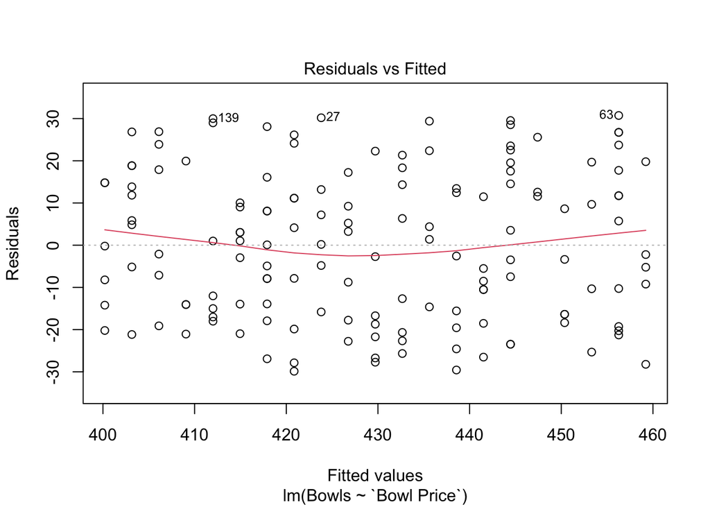

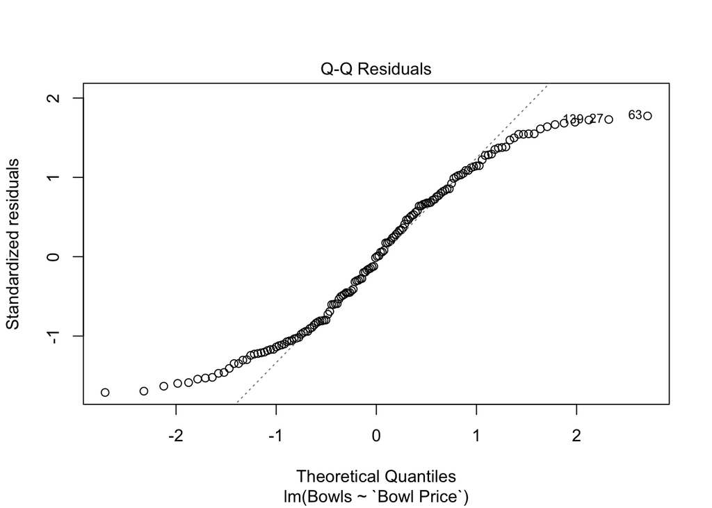

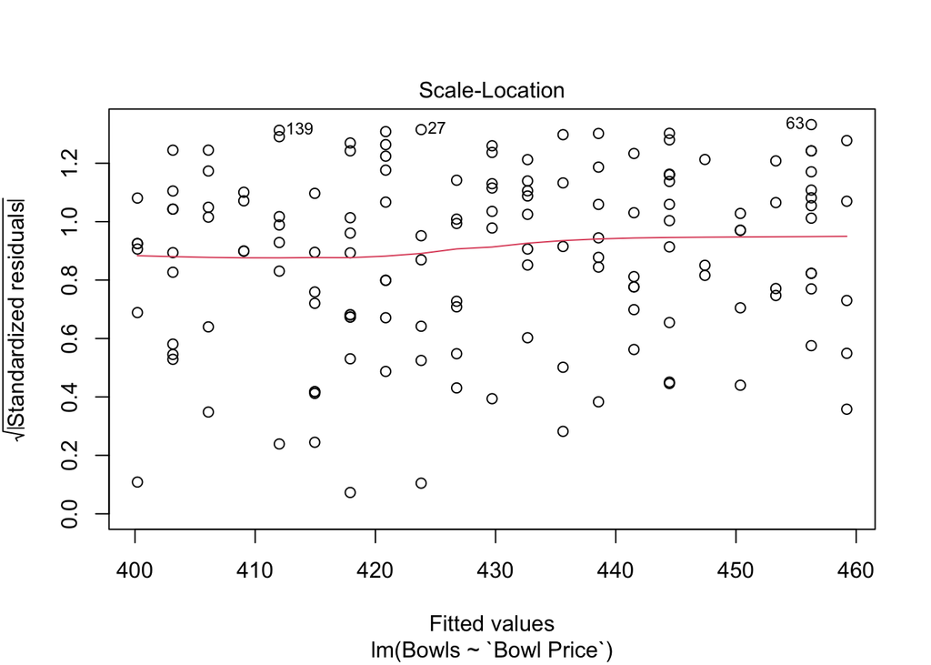

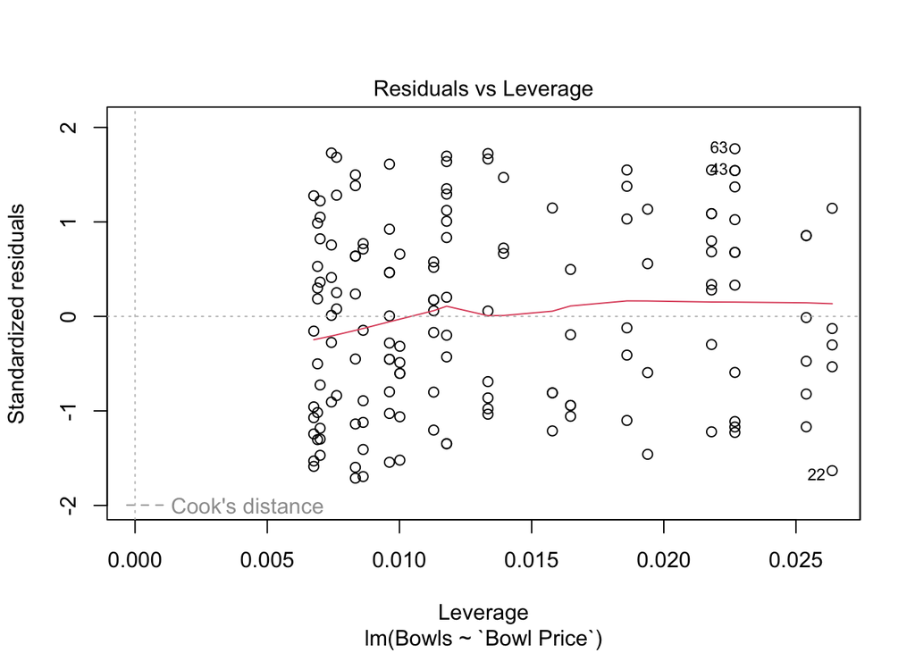

```r
#layout(matrix(c(1,2,3,4),2,2)) # opcional 4 graficos/pagina
plot(modelot0)
```

El primer y tercer gráfico muestran las predicciones en el eje x contra los residuos (simples en el primer gráfico o la raíz de los estandarizados en el tercero). En ambos, el objetivo es detectar atípicos y algún tipo de patrón visible.

Un patrón clásico es la forma de embudo, que implica bajos errores en predicciones bajas y altos errores en predicciones altas, un signo claro de que la variabilidad no es constante y estamos en presencia de no homocedasticidad.

Los gráficos presentados no parecen tener algun patrón adicional.

El segundo gráfico es un gráfico Q-Q para comparar la distribución de los residuales contra la curva normal. En la medida en que los cuantiles teóricos no se corresponden con los valores de los residuos encontrados, particularmente cuando hablamos de residuos positivos altos (parte derecha/arriba de la gráfica) entonces muy probablemente nuestor modelo no cumpla el supuesto de normalidad.

Por último, el cuarto gráfico chequea la presencia de puntos de influencia, casos que cambian significativamente el resultado de la regresión. Valores más allá de la curva roja (largas distancias de Cook) serían puntos de influencia que invitan a obtener más casos de combinaciones cercanas de variables dependientes para saber si el modelo actual es válido como está o simplemente se ve influenciado y dominado por esos puntos en regiones “escasas” de puntos. No parece ser el caso para nuestro modelo básico.

Por último, chequeemos la autocorrelación de residuos:

```r
library(lmtest)
```

```r
dwtest(modelot0)
```

```
##
##  Durbin-Watson test
##
## data:  modelot0
## DW = 2.2334, p-value = 0.9243
## alternative hypothesis: true autocorrelation is greater than 0
```

```r
dwtest(modelot1)
```

```
##
##  Durbin-Watson test
##
## data:  modelot1
## DW = 2.2744, p-value = 0.9561
## alternative hypothesis: true autocorrelation is greater than 0
```

Esta prueba de hipótesis prueba la autocorrelación de los datos con su dato inmediatamente anterior.

Rechazar la hipótesis nula implica una sospecha de autocorrelación en los residuos, esto es, el orden en que se presentan los datos permite explicar parcialmente patrones en los residuos.

Esto se presenta con frecuencia en datos en los que el factor tiempo u orden de recolección de los datos tiene algun efecto, (cuando la base de datos ha sido ordenada artificialmente también puede ocurrir).

En nuestro caso no se presentan valores p pequeños, por lo que descartamos autocorrelación de residuos.

Si se obtienen los diagnósticos de supuestos para el modelo completo, la situación es altamente similar.

# Conclusión

El modelo está incompleto y deben recogerse nuevos datos y trabajar más profundamente en la teoría.

# Aproximación de aprendizaje de máquina (machine learning)

Desde esta aproximación, lo que se busca es sacar el mejor provecho posible a los datos existentes (aprender de ellos) de modo que la capacidad predictiva sea máxima, aunque la explicabilidad teórica y la robustez estadística de los resultados como modelo del mundo no sean las ideales.

# Feature selection & overfitting

Si contamos con un conjunto específico de variables.

¿cómo seleccionar aquellas que puedan darnos el mejor poder predictivo/explicativo?.

El proceso para responder a esta pregunta se conoce como feature selection o selección de variables.

El objetivo (múltiple) de la selección de variables es obtener el mínimo número de variables que me den la máxima capacidad de predicción generalizada a datos nuevos o frescos.

En palabras de Einstein, un modelo debe ser “tan simple como sea posible, pero no simplista”.

Una razón fundamental para tratar de reducir el número de variables es eminentemente práctica, menos variables implican:

1. Menos gasto en la recolección adecuada y precisa de datos
2. Menos gasto computacional y por tanto, mayor velocidad de implementación
3. Mayor capacidad de realizar explicaciones teóricas

Una segunda razón poderosa para ajustar el número de variables es el riesgo de ocurrencia de un fenómeno denominado *sobreajuste u overfitting*.

Overfitting es, literalmente, aprender para el examen (base de entrenamiento) sin aprender para la vida (los datos frescos).

Siendo más precisos, mientras más parámetros se incluyan en un modelo, más probable es que el modelo se ajuste perfectamente a los datos desde los que aprendió y pierda capacidad de generalizar en datos nuevos.

En el caso de la regresión, cualquier variable que se incluya como posible predictora (independiente) va a generar un aumento en el r2.

Es por eso que el r2 no es una métrica adecuada cuando se usa la aproximación de machine learning en una regresión.

Una primera mejora es el uso del r2 ajustado, el cual penaliza la métrica por el número de parámetros (variables) que se utilizaron.

Una mejor opción es la utilización del criterio de información de Aikake (AIC), el cual también penaliza por el número de parámetros de una manera más formal, basado en la teoría de la información.

Mientras menor sea el valor del AIC, mejor es el modelo en comparación relativa con los otros modelos candidatos.

Veamos como funciona eso en los modelos que ya hemos creado.

```r
#obteniendo el AIC
AIC(modelot0)
```

```
## [1] 1271.524
```

```r
AIC(modelot1)
```

```
## [1] 1156.855
```

Sin embargo, el mecanismo más utilizado par evaluar la capacidad predictiva de un modelo es el uso de una métrica de predicción en datos frescos, como explicamos al principio.

Es por eso que separamos dos bases: una de entrenamiento y otra de validación.

Ahora vamos a hacer predicciones basadas en cada uno de nuestros modelos, y compararlas a partir de la raíz cuadrática media del error (RMSE).

```r
#PREDICCIONES

pred0<-predict(modelot0, maobase.test, se.fit=TRUE)
pred1<-predict(modelot1, maobase.test, se.fit=TRUE)

RMSE0<-sqrt(mean((pred0$fit-maobase.test$Bowls)^2))
RMSE1<-sqrt(mean((pred1$fit-maobase.test$Bowls)^2))
```

```r
RMSE0
```

```
## [1] 17.03353
```

```r
RMSE1
```

```
## [1] 10.71377
```

Pero, ¿será que nuestro modelo básico sufre de un pobre ajuste, y es posible conseguir un modelo que tenga mejores predicciones que el modelo completo sin utilizar todas las variables independientes?

Para saber eso, es necesario utilizar métodos de selección de variables en regresión.

# Feature selection en regression

1. Pasos sucesivos (stepwise)
2. Mejores subconjuntos (best subsets)

# Stepwise

Este método se basa en la idea de ir eligiendo secuencialmente las variables que deben incluirse o retirarse del modelo de acuerdo a un criterio. En el caso de R, el criterio es efectivamente la reducción en AIC. Se busca primero la variable que reduzca más el AIC frente a un modelo sin predictores; una vez incluida, se evalúa si la inclusión/exclusión de alguna variable adicional reduce el AIC, y de ser así, se incluye.

El proceso se detiene cuando ninguna inclusión/exclusión de variables disminuye el AIC.

Para poder ejecutarlo en R, es necesario haber creado primero el modelo completo. Todos los pasos secuenciasles son visibles en el resultado.

```r
#Feature selection
##stepwise
modelostep<- step(modelot1,direction="both")
```

```
## Start:  AIC=734.85
## Bowls ~ `Bowl Price` + Soda + Beer
##
##                Df Sum of Sq   RSS    AIC
## <none>                      20098 734.85
## - Beer          1    1601.4 21699 744.20
## - `Bowl Price`  1    7151.9 27250 777.91
## - Soda          1   19411.9 39510 832.89
```

Como puede observarse, el modelo final de AIC mínimo incluye 3 variables: Bowl Price, Soda y Beer. Miremos los resultados del modelo:

```r
summary(modelostep)
```

```
##
## Call:
## lm(formula = Bowls ~ `Bowl Price` + Soda + Beer, data = maobase.train)
##
## Residuals:
##     Min      1Q  Median      3Q     Max
## -27.623  -7.788  -1.020   8.471  27.779
##
## Coefficients:
##               Estimate Std. Error t value Pr(>|t|)
## (Intercept)  334.56208   31.01573  10.787  < 2e-16 ***
## `Bowl Price` -14.29183    1.99650  -7.158 3.85e-11 ***
## Soda           0.59429    0.05039  11.793  < 2e-16 ***
## Beer           0.23885    0.07051   3.387  0.00091 ***
## ---
## Signif. codes:  0 '***' 0.001 '**' 0.01 '*' 0.05 '.' 0.1 ' ' 1
##
## Residual standard error: 11.81 on 144 degrees of freedom
## Multiple R-squared:  0.7775, Adjusted R-squared:  0.7729
## F-statistic: 167.8 on 3 and 144 DF,  p-value: < 2.2e-16
```

# Best subsets

Dado un número de variables máximo n, la técnica de mejores subconjuntos busca todos los subconjuntos de tamaño k donde k<=n. Este método no trabaja secuencialmente, sino que hace todos los modelos posibles para cada tamaño n.

Como métrica de escogencia utiliza algo conocido como el Cp de Mallows, el cual tiene una fuerte relación con el AIC.

```r
##best subsets
library(MASS)
library(leaps)
```

```r
#nbest (numero de modelos por cada k) es por defecto 1 y nvmax es por defecto 8 (k maximo)
modelsub<-regsubsets(Bowls~.,data=maobase.train, nbest=1, nvmax=6, method = "exhaustive")
summary(modelsub)
```

```
## Subset selection object
## Call: regsubsets.formula(Bowls ~ ., data = maobase.train, nbest = 1,
##     nvmax = 6, method = "exhaustive")
## 3 Variables  (and intercept)
##              Forced in Forced out
## `Bowl Price`     FALSE      FALSE
## Soda             FALSE      FALSE
## Beer             FALSE      FALSE
## 1 subsets of each size up to 3
## Selection Algorithm: exhaustive
##          `Bowl Price` Soda Beer
## 1  ( 1 ) " "          "*"  " "
## 2  ( 1 ) "*"          "*"  " "
## 3  ( 1 ) "*"          "*"  "*"
```

Los asteriscos marcan si la variable está incluida o no en el modelo, y cada línea marca un k.

Notemos que el mejor subconjunto de 3 es el 3.

No necesariamente eso ocurre: stepwise, por su naturaleza secuencial, no evalúa todas las opciones posibles, sino solo un subconjunto de ellas.

Una vez se han generado los modelos, podemos ver algunas características de ellos:

Obtener r2 ajustado

```r
summary(modelsub)$adjr2
```

```
## [1] 0.6702294 0.7565123 0.7729155
```

Obtener el cp

```r
summary(modelsub)$cp
```

```
## [1] 68.02024 13.47392  4.00000
```

Obtener el BIC (medida similar al AIC)

```r
summary(modelsub)$bic
```

```
## [1] -155.2008 -196.1138 -202.4629
```

Observe que el r2 ajustado aumenta con modelo con 3 variables, y que tanto Cp como BIC son consistentes con el AIC, por lo que el modelo obtenido por los diferentes metodos coinciden con la inclusión de las tres variables.

Miremos como se desempeña en la base de validación:

Desempeño en la base de validación

```r
predstep<-predict(modelostep, maobase.test, se.fit=TRUE)
RMSEstep<-sqrt(mean((predstep$fit-maobase.test$Bowls)^2))
```

```r
RMSE0
```

```
## [1] 17.03353
```

```r
RMSE1
```

```
## [1] 10.71377
```

```r
RMSEstep
```

```
## [1] 10.71377
```

Nuestro modelo stepwise con las tres variables y el modelo con las tres variables es el de mejor desempeño de los modelos generados.